Luis Antonio Ortega Andrés  
Antonio Coín Castro

# Sumador cuántico de dos bits

```python
from qiskit import QuantumCircuit, QuantumRegister, Aer, IBMQ, execute
from qiskit.visualization import plot_histogram, plot_bloch_multivector
from qiskit_textbook.tools import array_to_latex

%matplotlib inline

# Load IBM account
provider = IBMQ.load_account()
```

## Semisumador clásico

El circuito clásico para suma de dos bits (también conocido como semisumador) es el siguiente:

[figure not shown]

En resumidas cuentas, queremos implementar el comportamiento de la siguiente tabla:

| Bit 1 | Bit 2 | Carry | Suma |
| --- | --- | --- | --- |
| 0 | 0 | 0 | 0 |
| 0 | 1 | 0 | 1 |
| 1 | 0 | 0 | 1 |
| 1 | 1 | 1 | 0 |

En general, para representar la suma de dos bits necesitamos un número de dos bits: la suma puede ser $00$, $01$, ó $10$. El bit más significativo se conoce como bit de *carry*, que solo es $1$ cuando sumemos $1+1$; y el bit menos significativo es el bit de *suma*, que vale $1$ si y solo si sumamos dos bits distintos ($1+0$ ó $0+1$). Hecho este análisis, vemos que la puerta XOR representa perfectamente el bit de suma, mientras que el bit de carry puede conseguirse con la puerta AND.

## Semisumador cuántico

Queremos reproducir ahora el comportamiento del semisumador clásico con un circuito cuántico. Para ello debemos buscar puertas cuánticas equivalentes a la XOR y la AND, que además sean reversibles.

En primer lugar, planteamos un circuito con 4 qubits, donde los dos primeros representarán la entrada, y los dos últimos la salida (concretamente, $q_2$ será el bit de suma y $q_3$ el de carry). Para probar nuestro circuito usaremos el caso más "difícil", que es el de sumar $1+1$, por lo que transformamos las dos entradas al estado $|1\rangle$ con una puerta $X$.

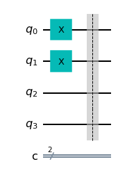

```python
circuit = QuantumCircuit(4, 2)

# Input
circuit.x(0)
circuit.x(1)
circuit.barrier()

circuit.draw('mpl')
```

Para implementar el (qu)bit de suma, que guardaremos en $q_2$, necesitamos simular el comportamiento de la puerta XOR. Para esto usaremos la puerta CNOT, de forma que podamos analizar cuándo alguna de las entradas vale $1$ y la otra $0$. Como no queremos sobreescribir la entrada, podemos usar dos puertas CNOT para guardar el resultado en $q_2$:

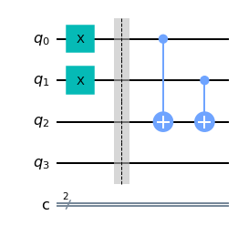

```python
# Compute 'S' bit
circuit.cnot(0, 2)
circuit.cnot(1, 2)
circuit.draw('mpl')
```

De esta forma, en $q_2$ habrá un $|0\rangle$ si $q_0=q_1$, ya que hacemos *flip* de $q_2$ dos veces, y en otro caso habrá un $|1\rangle$ (un único *flip*).

Para calcular el bit de acarreo, la puerta que usaremos es la [puerta de Toffoli](https://en.wikipedia.org/wiki/Toffoli_gate). Esta puerta puede describirse como una puerta CNOT con dos entradas de control, que actúa sobre su tercera entrada solo cuando los dos valores de control valgan $1$. Esto es justo lo que queremos para guardar el acarreo en $q_3$.

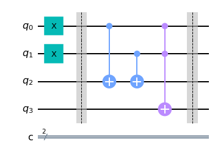

```python
# Compute 'C' bit
circuit.toffoli(0, 1, 3)
circuit.barrier()
circuit.draw('mpl')
```

Al utilizar solamente puertas NOT y CNOT, e inicializar los qubits a $|0\rangle$ o $|1\rangle$, el circuito no presenta aleatoriedad, permitiendo sumar los valores de los bits de entrada. Podemos comprobar esto analizando el estado de los dos últimos qubits, y viendo cómo su estado conjunto colapsa al valor deseado en este caso.

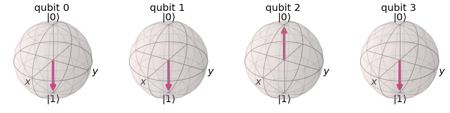

```python
backend = Aer.get_backend('statevector_simulator')
psi = execute(circuit, backend).result().get_statevector()
plot_bloch_multivector(psi)
```

Finalmente añadimos una medición en los dos últimos qubits y ejecutamos el circuito repetidas veces, para ver los resultados. Vemos que obtenemos el estado $|10\rangle$ en todos los casos (2 en binario), lo cual indica que el circuito funciona correctamente.

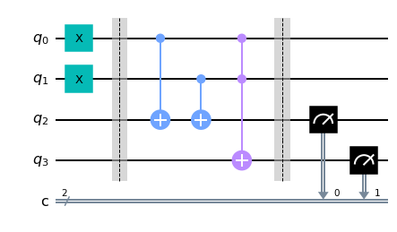

```python
# Output
circuit.measure([2, 3], [0, 1])
circuit.draw('mpl')
```

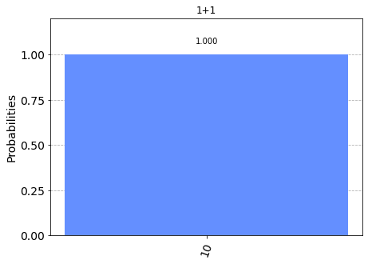

```python
backend = provider.get_backend('ibmq_qasm_simulator')
counts = execute(circuit, backend, shots=1024).result().get_counts(circuit)
plot_histogram(counts, title="1+1")
```

Finalmente creamos una función que construya un circuito inicializado con los valores que queramos, y comprobamos que funciona bien en todos los casos.

```python
def add_bits(b1, b2):
    circuit = QuantumCircuit(4, 2)
    if b1:
        circuit.x(0)
    if b2:
        circuit.x(1)

    circuit.cnot(0, 2)
    circuit.cnot(1, 2)
    circuit.toffoli(0, 1, 3)
    circuit.measure([2, 3], [0, 1])

    return circuit

# Create circuits
c1 = add_bits(0, 0)
c2 = add_bits(0, 1)
c3 = add_bits(1, 0)
```

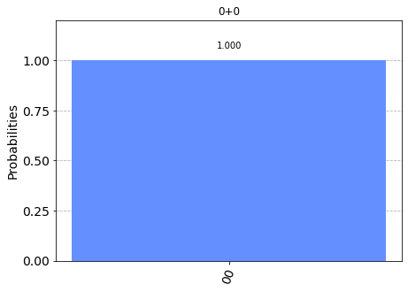

```python
counts1 = execute(c1, backend, shots=1024).result().get_counts(c1)
plot_histogram(counts1, title="0+0")
```

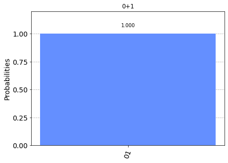

```python
counts2 = execute(c2, backend, shots=1024).result().get_counts(c2)
plot_histogram(counts2, title="0+1")
```

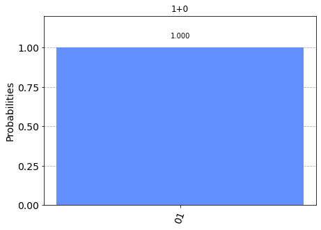

```python
counts3 = execute(c3, backend, shots=1024).result().get_counts(c3)
plot_histogram(counts3, title="1+0")
```